# Biostatistical Computing, PHC 6068

R graphics

Zhiguang Huo (Caleb)

Monday September 11, 2017

# Outline: what you expect to learn

- plot basics
  - scattered plot
  - margins
  - histogram and heatmap
- ggplot2
- lattice

# Plotting in R

R is powerful to visualize your data.

- plot(): a generic plotting function
  - points(): add points to the plot.
  - lines(), abline(): add lines
  - text(): add text
  - legend(): add legend
- hist(): histogram
- image(), heatmap(): heatmaps
- boxplot(): boxplot
- curve(): any function curve
- contour(): contour plot

# scattered plot

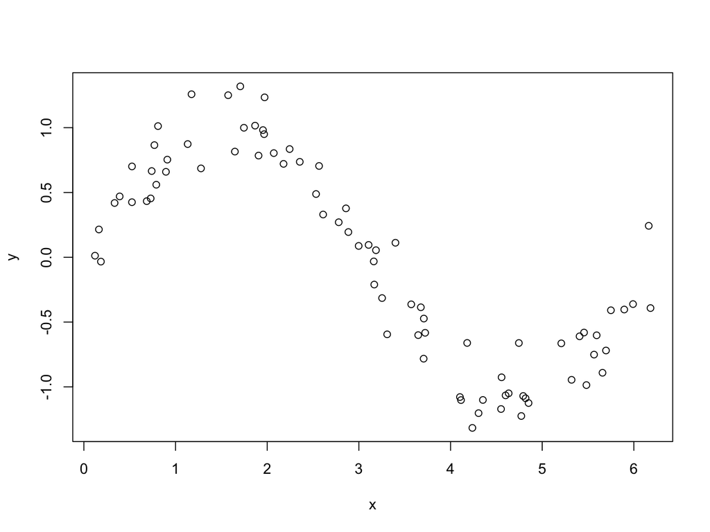

```r
n <- 80
set.seed(32611)
x <- sort(runif(n, min = 0, max=2*pi))
y <- sin(x) + rnorm(n, mean = 0, sd = 0.2)
plot(x,y)
```

# Type

- “p”: for points
- “l”: for lines
- “b” for both,
- “o” for both ‘overplotted’,
- “n” for no plotting.

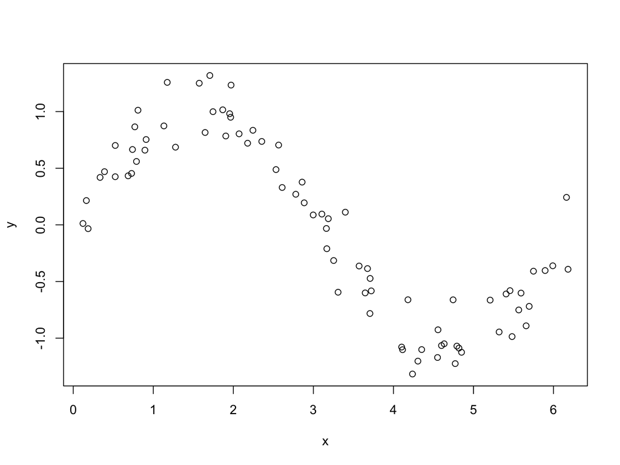

```r
plot(x,y, type="p") ## default is "p"
```

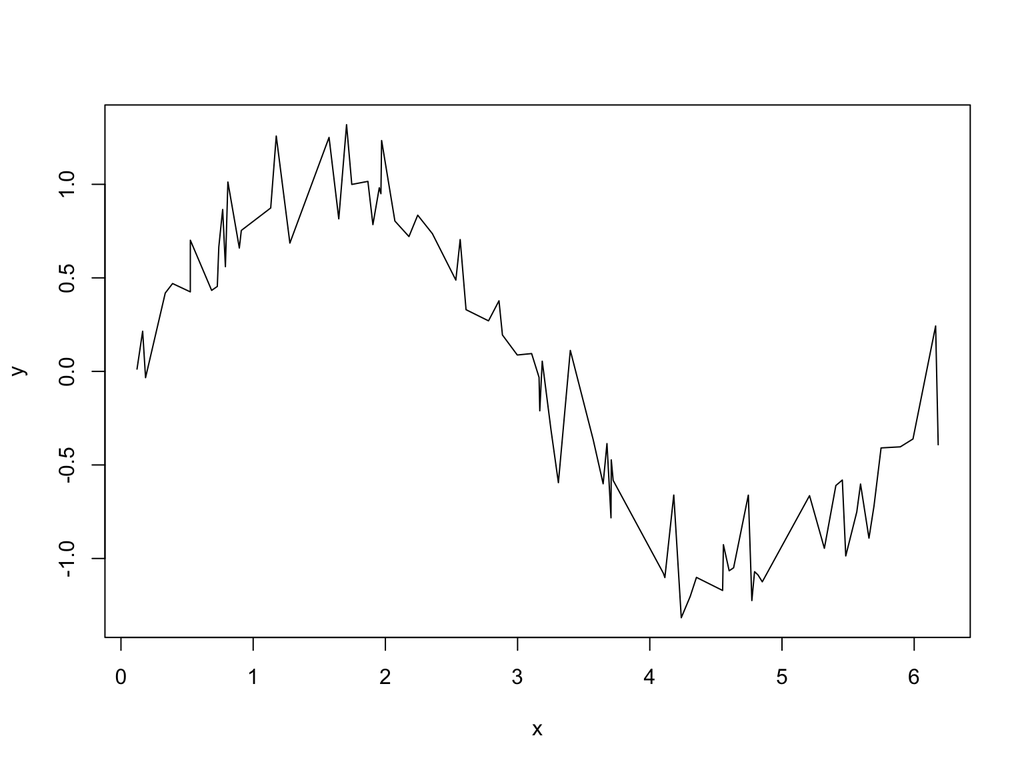

```r
plot(x,y, type="l")
```

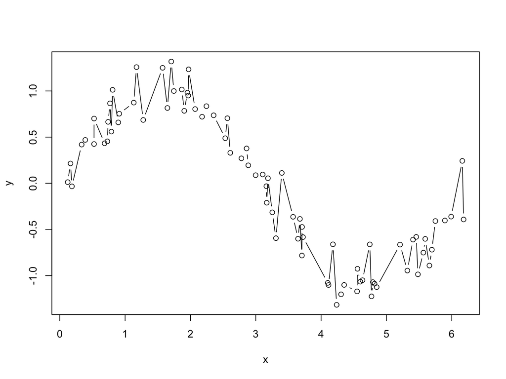

```r
plot(x,y, type="b")
```

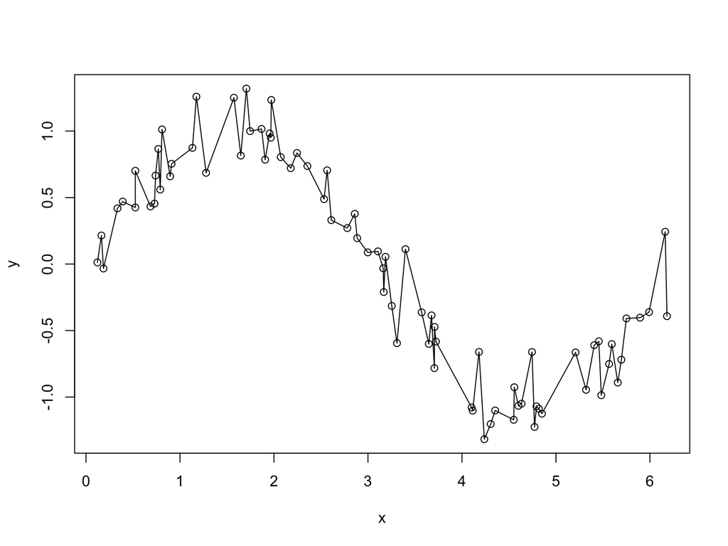

```r
plot(x,y, type="o")
```

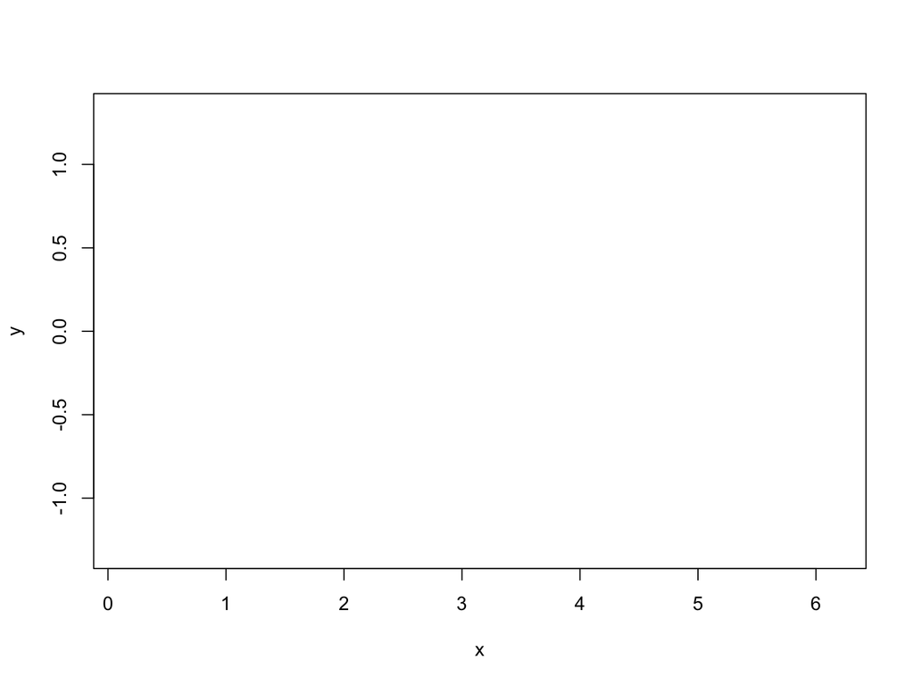

```r
plot(x,y, type="n")
```

# Labels

- main: title
- xlab: x labels
- ylab: y labels

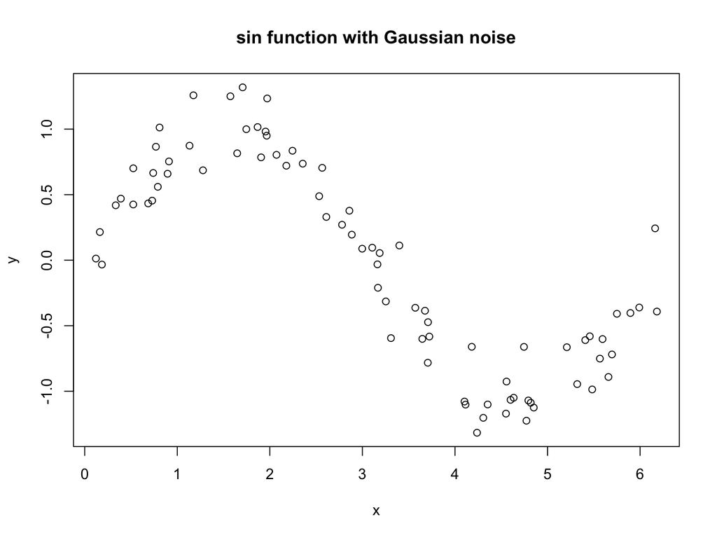

```r
plot(x,y, main="sin function with Gaussian noise") # default xlab and ylab are the variable names of the arguments
```

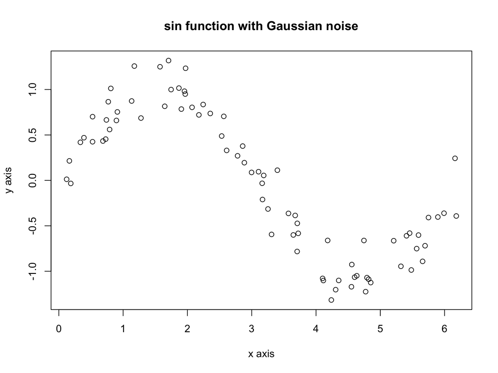

```r
plot(x,y, main="sin function with Gaussian noise",
     xlab="x axis", ylab="y axis")
```

# Text and Symbol Size

- cex: number indicating the amount by which plotting text and symbols should be scaled relative to the default. 1=default, 1.5 is 50% larger, 0.5 is 50% smaller, etc.
- cex.axis magnification of axis annotation relative to cex
- cex.lab magnification of x and y labels relative to cex
- cex.main magnification of titles relative to cex
- cex.sub magnification of subtitles relative to cex

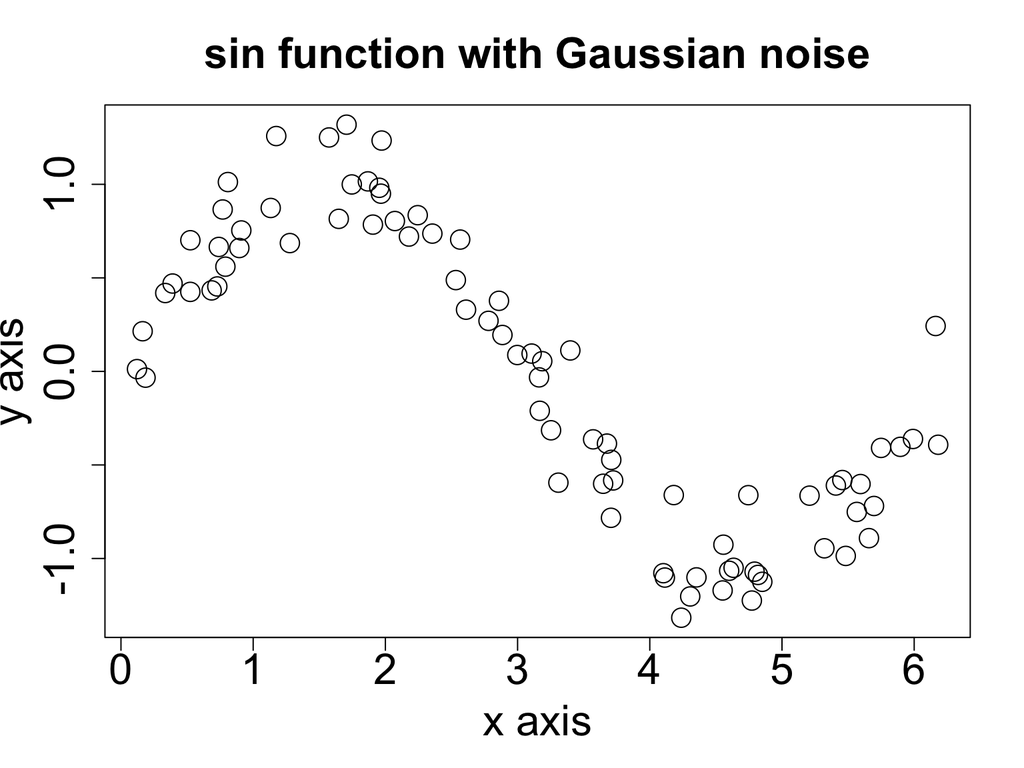

```r
plot(x,y, main="sin function with Gaussian noise",
     xlab="x axis", ylab="y axis",
     cex=2, cex.axis=2, cex.lab=2, cex.main=2, cex.sub=2)
```

# Point type

- pch is an argument for point typs

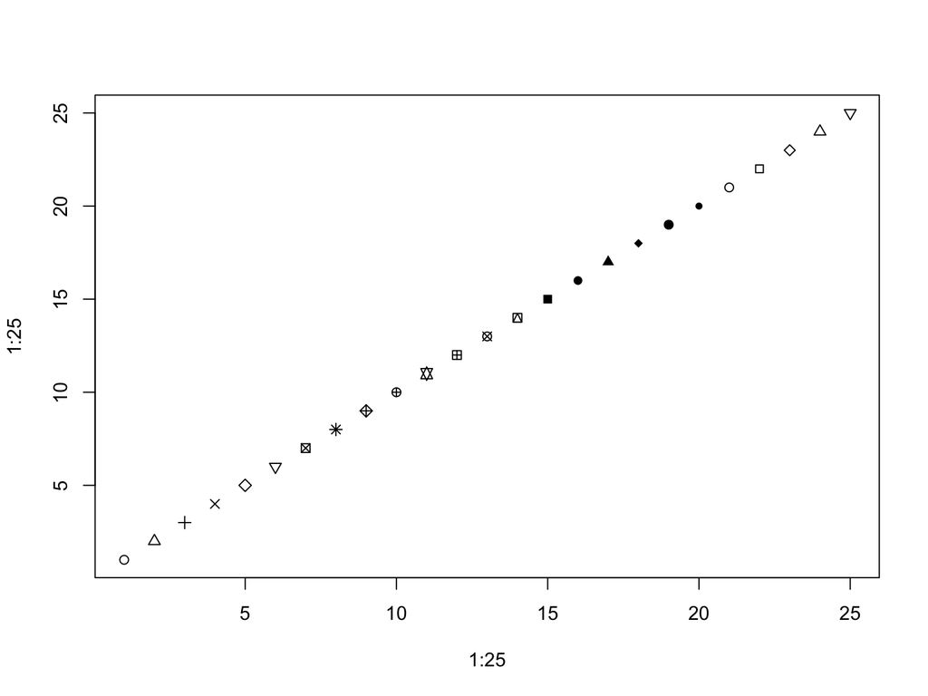

```r
plot(1:25,1:25,pch=1:25)
```

- use pch = 19

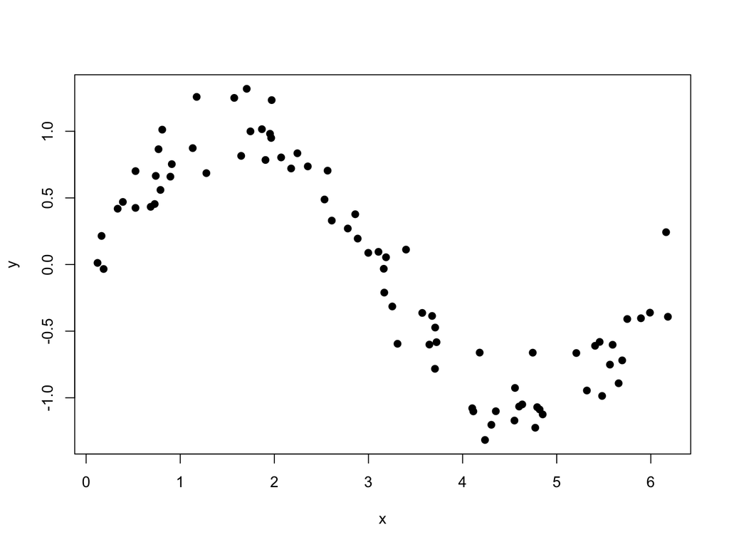

```r
plot(x,y, pch=19)
```

# Multiple plots

- Use par() with mfcol or mfrow settings to create a nxm grid of figures.
  - mfcol=c(nr, nc) adds figures by column
  - mfrow=c(nr, nc) adds figures by row

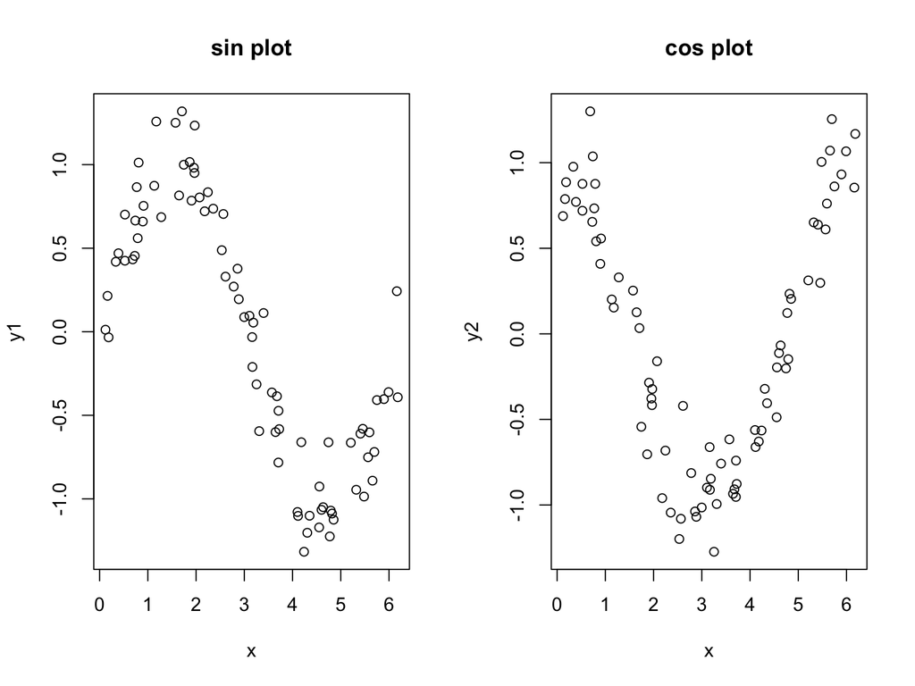

```r
n <- 80
set.seed(32611)
x <- sort(runif(n, min = 0, max=2*pi))
y1 <- sin(x) + rnorm(n, mean = 0, sd = 0.2)
y2 <- cos(x) + rnorm(n, mean = 0, sd = 0.2)

par(mfrow=c(1,2))
plot(x,y1, main="sin plot")
plot(x,y2, main="cos plot")
```

# Lines

- lty: line type. see the chart below.

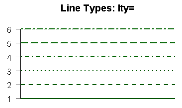

- lwd line width relative to the default (default=1). 2 is twice as wide.

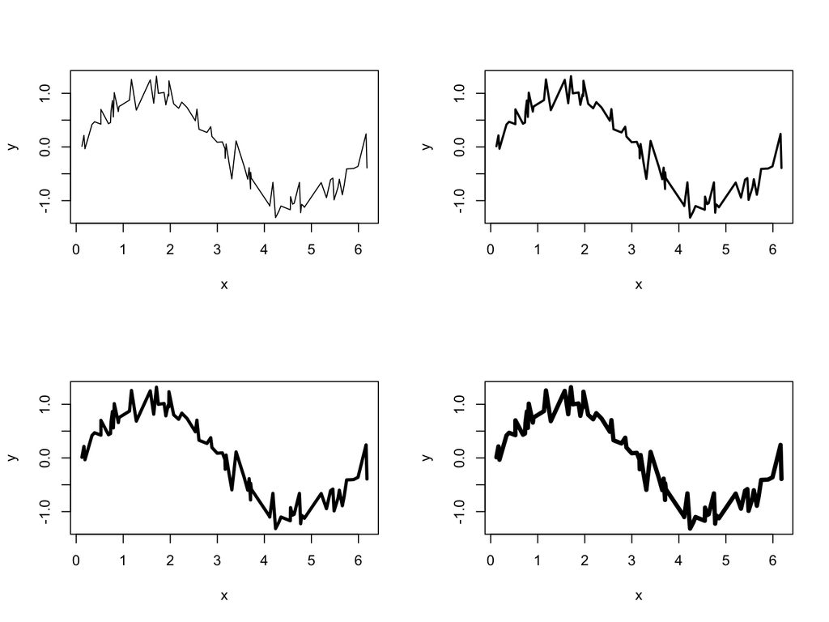

```r
par(mfrow=c(2,2))
plot(x,y, type="l",lwd=1)
plot(x,y, type="l",lwd=2)
plot(x,y, type="l",lwd=3)
plot(x,y, type="l",lwd=4)
```

# color

- col argument to control the color
- col = 1:8 for eight basic colors
- a string for 657 available colors (check out colors() )
- RGB: “#rrggbb”.
  - rr: red intensity, 00-FF (Hexadecimal)
  - gg: green intensity, 00-FF (Hexadecimal)
  - bb: blue intensity, 00-FF (Hexadecimal)
  - e.g. #FF0000 represent red color.

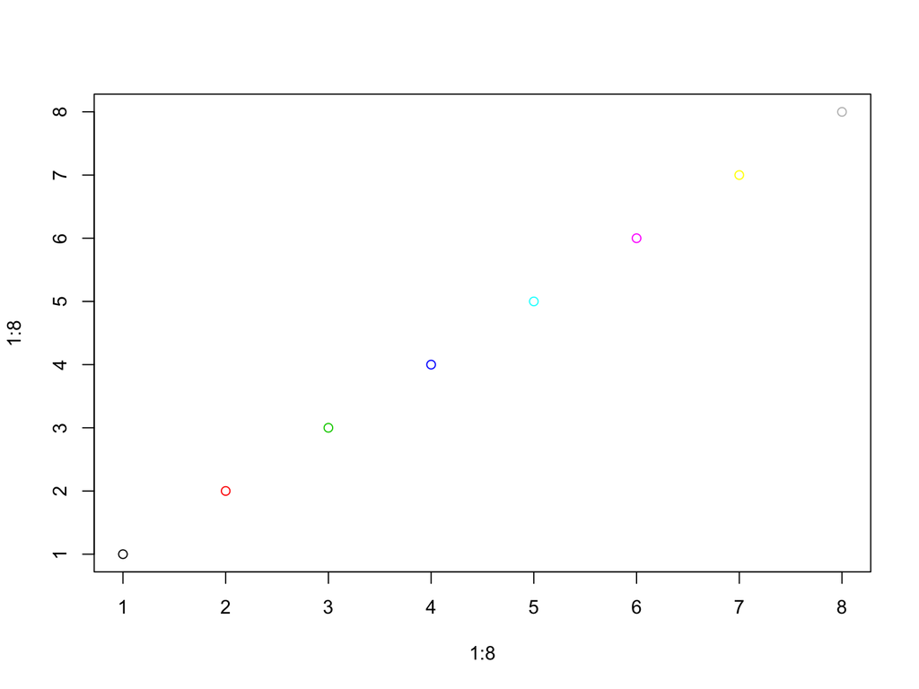

```r
plot(1:8,1:8, col=1:8)
```

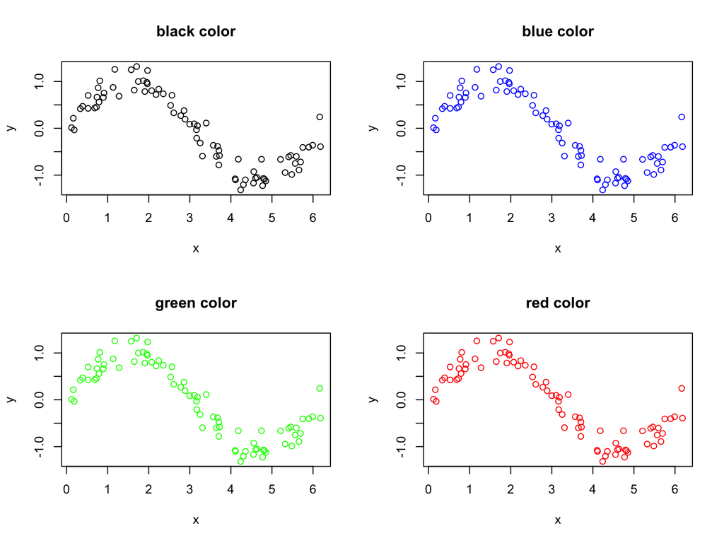

```r
par(mfrow=c(2,2))
plot(x,y, main = "black color") ## default is black
plot(x,y, main = "blue color", col=4) ## basic color option 1:8
plot(x,y, main = "green color", col='green') ## find colors from colors()
plot(x,y, main = "red color", col='#FF0000') ## RGB mode
```

# More on colors

- More on color argument for plot
  - col Default plotting color. Some functions (e.g. lines) accept a vector of values that are recycled.
  - col.axis color for axis annotation
  - col.lab color for x and y labels
  - col.main color for titles
  - col.sub color for subtitles
  - fg plot foreground color (axes, boxes - also sets col= to same)
  - bg plot background color
- You can also create a vector of n contiguous colors using the functions rainbow(n), heat.colors(n), terrain.colors(n), topo.colors(n), and cm.colors(n).

# text

- After create a plot, you can add text to it by text.

```r
letters[1:10] ## letters contain a-z
```

```
##  [1] "a" "b" "c" "d" "e" "f" "g" "h" "i" "j"
```

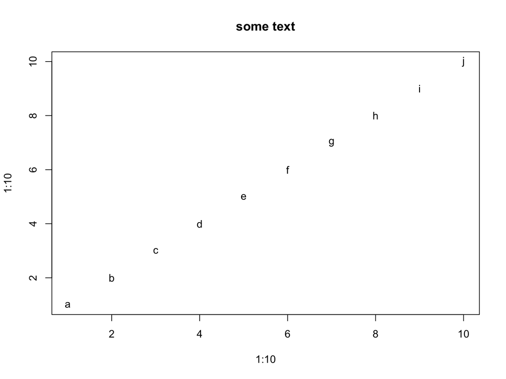

```r
plot(x=1:10, y=1:10, type="n", main = "some text")
text(x = 1:10, y=1:10, labels = letters[1:10])
```

# curve

- curve() allow you plot any function

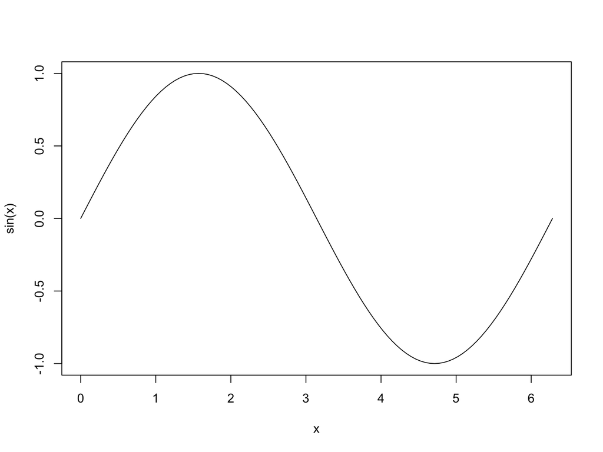

```r
curve(sin, from = 0, to = 2*pi)
```

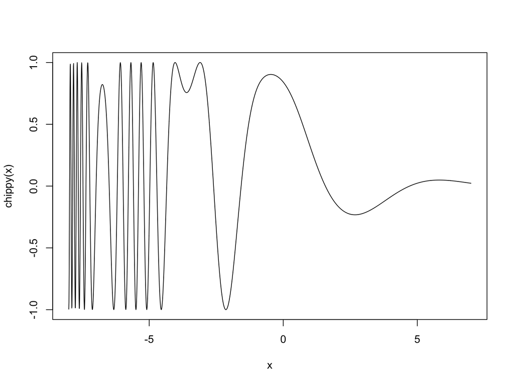

```r
chippy <- function(x) sin(cos(x)*exp(-x/2))
curve(chippy, -8, 7, n = 2001) # n specify number of points used to draw the curve, default n = 101
```

# legend

- ?legend for more options

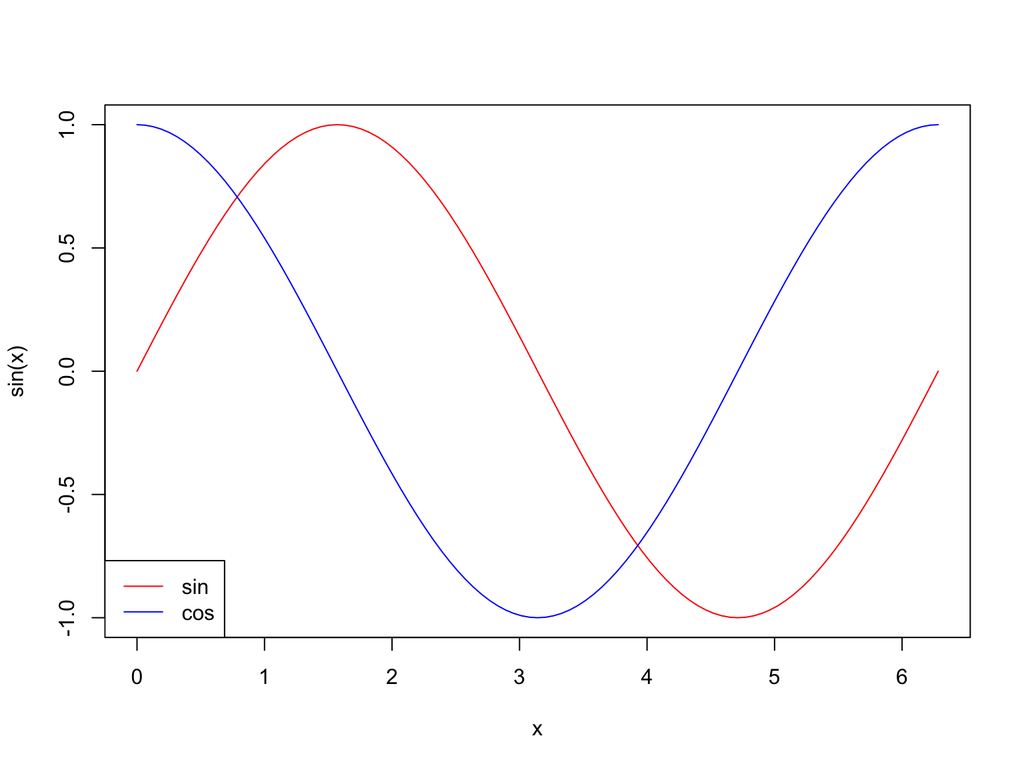

```r
curve(sin, 0, 2*pi, col=2)
curve(cos, 0, 2*pi, col=4, add=T) ## add=T to overlay a new curve on top of the original figure
legend("bottomleft", legend = c("sin", "cos"), col = c(2,4),lty = 1)
```

# margin

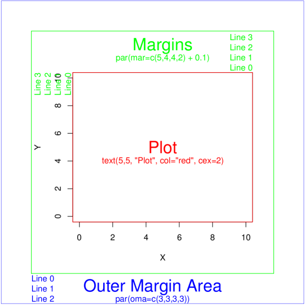

- to change margins, use the par() function, with the argument mar.

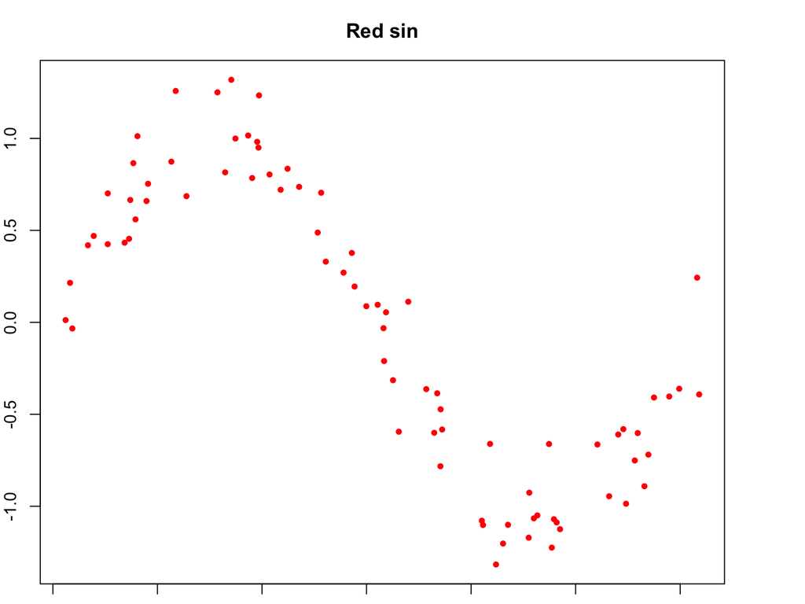

```r
par(mar=c(1,2,3,4)) # bottem, left, top, right order, inner margin
plot(x, y, main="Red sin", pch=20, col="red")
```

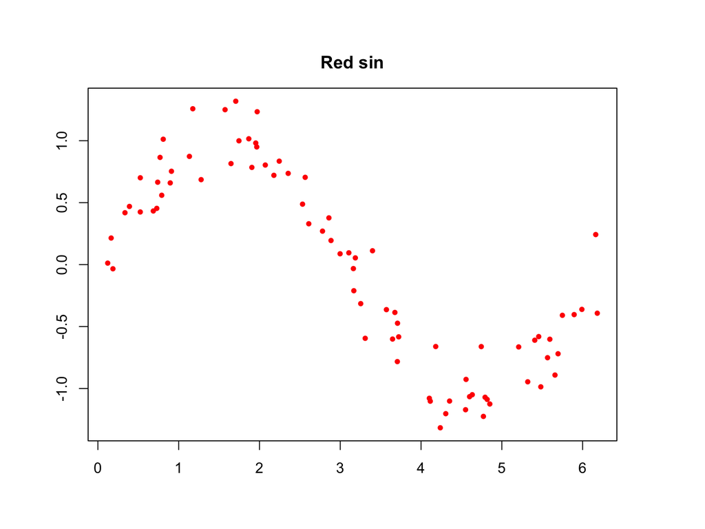

```r
par(oma = c(4,3,2,1), mar=c(1,2,3,4)) # bottem, left, top, right order, inner margin and outer margin
plot(x, y, main="Red sin", pch=20, col="red")
```

# save plot

- Figures can be saved as .pdf, .png, .jpeg, .bmp, .tiff by using pdf(), png(), jpeg(), bmp(), tiff().
- PDF format is recommended since it is vector format. resize the figure woun’t affect the quality.

```r
pdf("sinFunction.pdf")
n <- 80
set.seed(32611)
x <- sort(runif(n, min = 0, max=2*pi))
y <- sin(x) + rnorm(n, mean = 0, sd = 0.2)
plot(x,y)
dev.off()
```

# IRIS data example

```r
data(iris)
head(iris)
```

```
##   Sepal.Length Sepal.Width Petal.Length Petal.Width Species
## 1          5.1         3.5          1.4         0.2  setosa
## 2          4.9         3.0          1.4         0.2  setosa
## 3          4.7         3.2          1.3         0.2  setosa
## 4          4.6         3.1          1.5         0.2  setosa
## 5          5.0         3.6          1.4         0.2  setosa
## 6          5.4         3.9          1.7         0.4  setosa
```

```r
str(iris)
```

```
## 'data.frame':    150 obs. of  5 variables:
##  $ Sepal.Length: num  5.1 4.9 4.7 4.6 5 5.4 4.6 5 4.4 4.9 ...
##  $ Sepal.Width : num  3.5 3 3.2 3.1 3.6 3.9 3.4 3.4 2.9 3.1 ...
##  $ Petal.Length: num  1.4 1.4 1.3 1.5 1.4 1.7 1.4 1.5 1.4 1.5 ...
##  $ Petal.Width : num  0.2 0.2 0.2 0.2 0.2 0.4 0.3 0.2 0.2 0.1 ...
##  $ Species     : Factor w/ 3 levels "setosa","versicolor",..: 1 1 1 1 1 1 1 1 1 1 ...
```

# boxplot

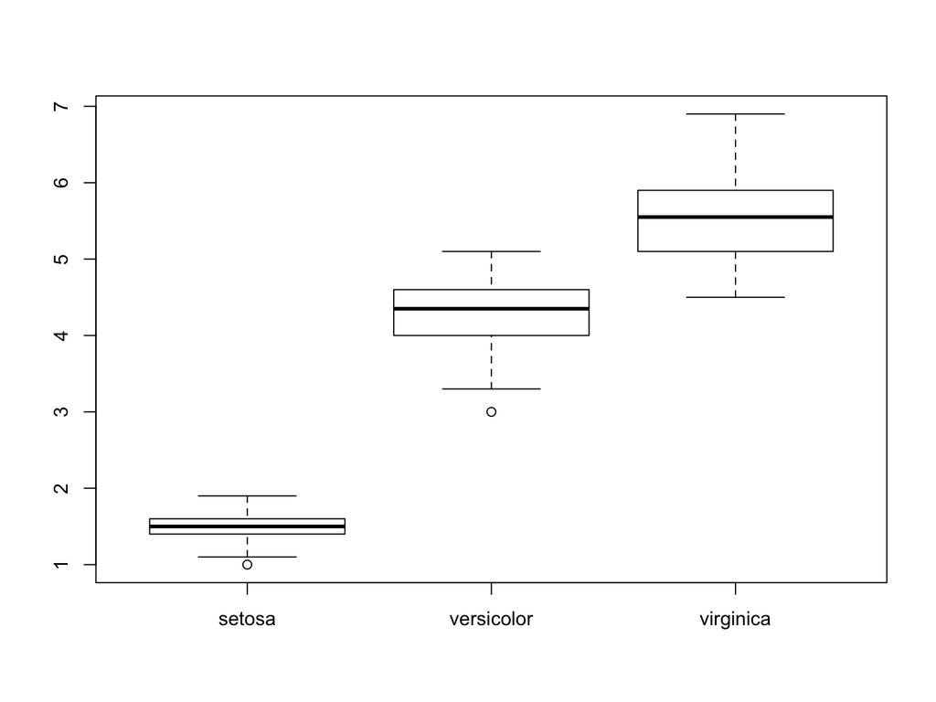

```r
boxplot(Petal.Length ~ Species, data = iris)
```

```r
names(iris)
```

```
## [1] "Sepal.Length" "Sepal.Width"  "Petal.Length" "Petal.Width"
## [5] "Species"
```

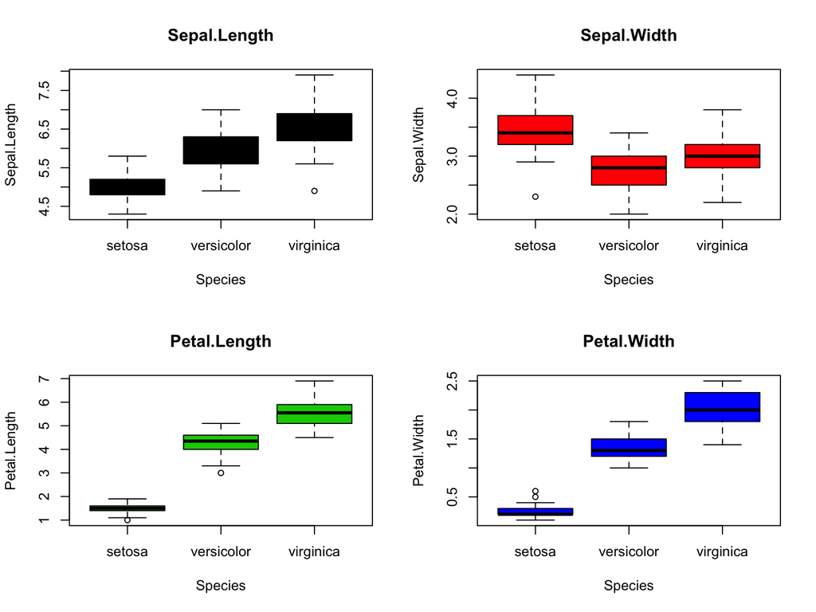

```r
par(mfrow = c(2,2))
for(i in 1:4){
  aname <- names(iris)[i]
  boxplot(iris[[i]] ~ iris$Species, xlab="Species", col=i, ylab=aname, main=aname)
}
```

# histogram

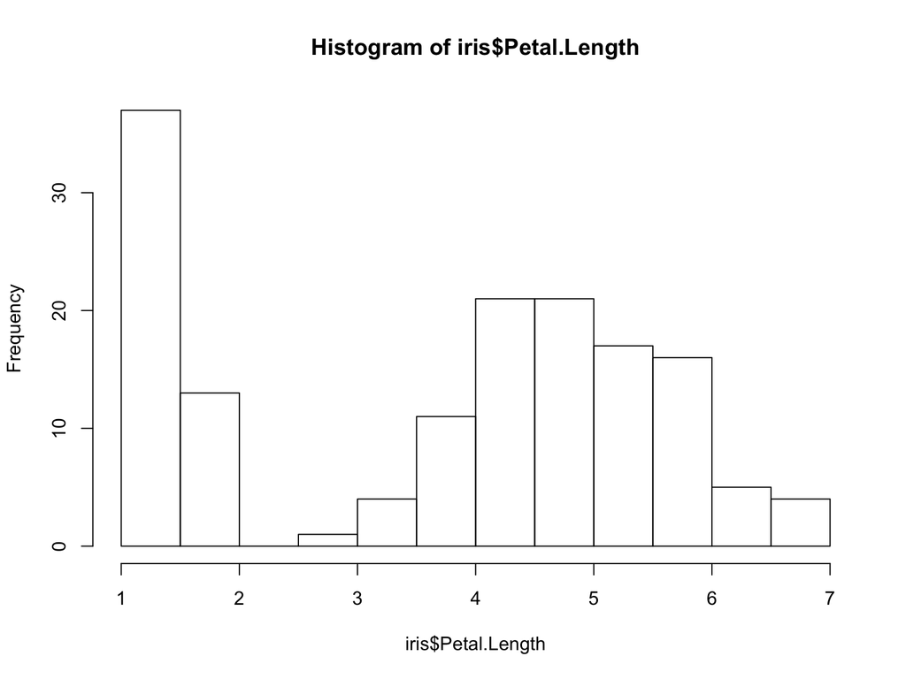

```r
hist(iris$Petal.Length)
```

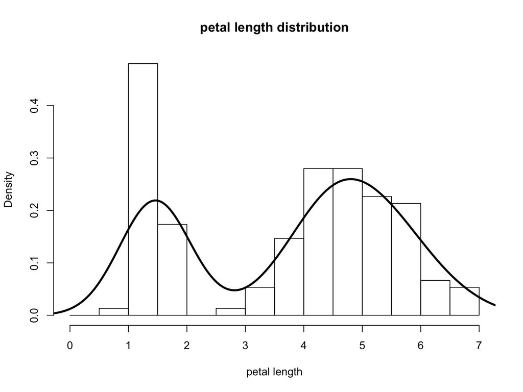

```r
density.est = density(iris$Petal.Length)
hist(iris$Petal.Length, freq=FALSE, breaks=seq(0,7,0.5),
     xlab="petal length", main="petal length distribution")
lines(density.est, lwd=3)
```

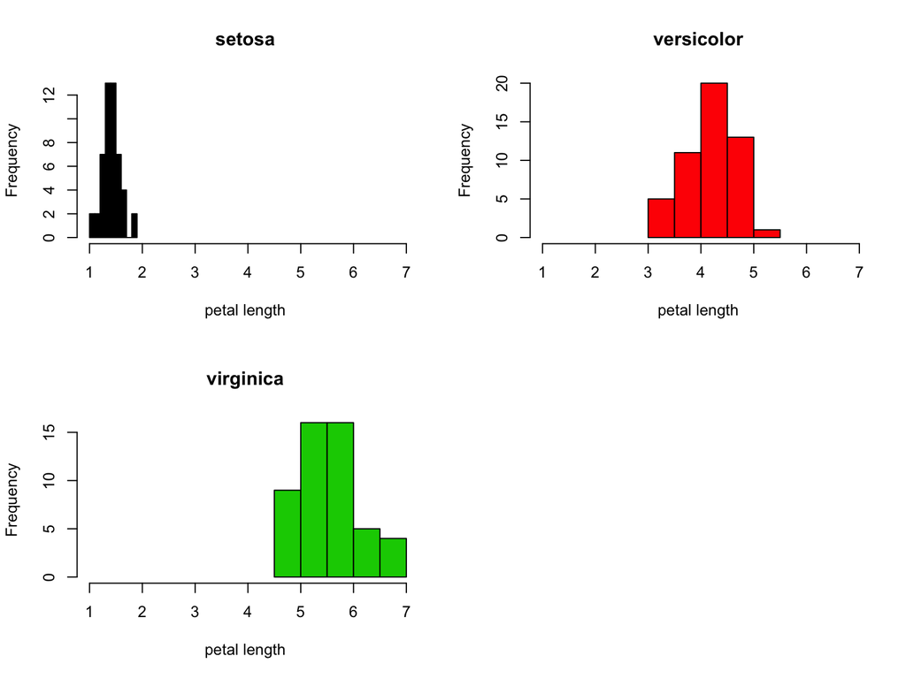

```r
par(mfrow = c(2,2))
xlims <- range(iris$Petal.Length)
uniqueSpecies <- levels(iris$Species)
for(i in 1:3){
  aspecies <- uniqueSpecies[i]
  sampleSelection <- iris$Species==aspecies
  adata <- iris$Petal.Length[sampleSelection]
  hist(adata, col=i, xlim=xlims, xlab="petal length",main=aspecies)
}
```

# heatmap

- image
- heatmap
- lattice package

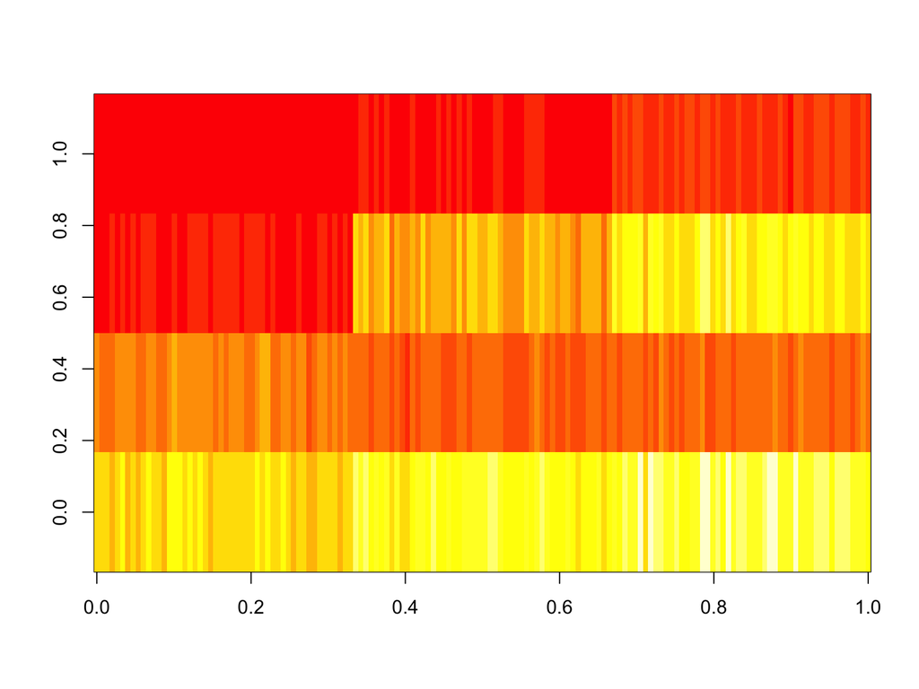

```r
matrix <- as.matrix(iris[,1:4])
image(matrix)
```

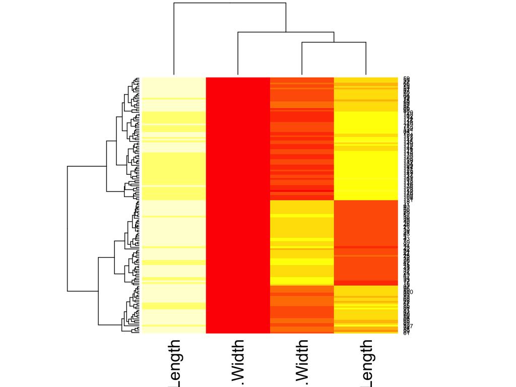

```r
heatmap(matrix)
```

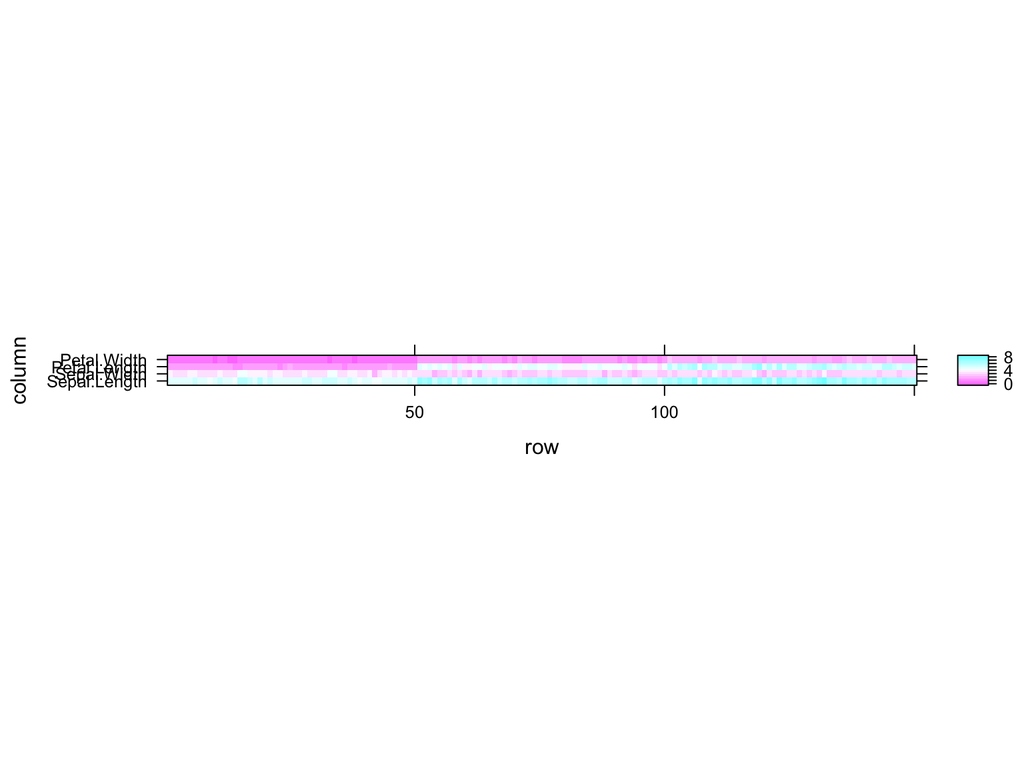

```r
library(lattice)
levelplot(matrix)
```

# ggplot2

# lattice plot

- http://www.isid.ac.in/~deepayan/R-tutorials/labs/04_lattice_lab.pdf
- http://www.statmethods.net/advgraphs/trellis.html